# CaseStudy2DDS

Ranjan

2/4/2022

##packages

```r
library(tidyverse)
library(dplyr)
library(caret)
library(class)
##install.packages("vis_miss")
##library(vis_miss)
##install.packages("earth")
library(earth)
library(GGally)
library(readxl)
```

### Load Raw Data

```r
data <- read.csv("CaseStudy2-data.csv",header = TRUE)
head(data)
```

```
##   ID Age Attrition    BusinessTravel DailyRate             Department
## 1  1  32        No     Travel_Rarely       117                  Sales
## 2  2  40        No     Travel_Rarely      1308 Research & Development
## 3  3  35        No Travel_Frequently       200 Research & Development
## 4  4  32        No     Travel_Rarely       801                  Sales
## 5  5  24        No Travel_Frequently       567 Research & Development
## 6  6  27        No Travel_Frequently       294 Research & Development
##   DistanceFromHome Education   EducationField EmployeeCount EmployeeNumber
## 1               13         4    Life Sciences             1            859
## 2               14         3          Medical             1           1128
## 3               18         2    Life Sciences             1           1412
## 4                1         4        Marketing             1           2016
## 5                2         1 Technical Degree             1           1646
## 6               10         2    Life Sciences             1            733
##   EnvironmentSatisfaction Gender HourlyRate JobInvolvement JobLevel
```

[output cut: 41 more lines]

```r
length(data)
```

```
## [1] 36
```

```r
#View(data)
```

#checking missing data

```r
colSums(is.na(data))
```

```
##                       ID                      Age                Attrition
##                        0                        0                        0
##           BusinessTravel                DailyRate               Department
##                        0                        0                        0
##         DistanceFromHome                Education           EducationField
##                        0                        0                        0
##            EmployeeCount           EmployeeNumber  EnvironmentSatisfaction
##                        0                        0                        0
##                   Gender               HourlyRate           JobInvolvement
##                        0                        0                        0
##                 JobLevel                  JobRole          JobSatisfaction
##                        0                        0                        0
##            MaritalStatus            MonthlyIncome              MonthlyRate
##                        0                        0                        0
##       NumCompaniesWorked                   Over18                 OverTime
##                        0                        0                        0
##        PercentSalaryHike        PerformanceRating RelationshipSatisfaction
##                        0                        0                        0
##            StandardHours         StockOptionLevel        TotalWorkingYears
##                        0                        0                        0
##    TrainingTimesLastYear          WorkLifeBalance           YearsAtCompany
##                        0                        0                        0
##       YearsInCurrentRole  YearsSinceLastPromotion     YearsWithCurrManager
##                        0                        0                        0
```

```r
###sum(is.na(data))--- 0
```

## VIsualizing missing data

There is no missing values in the data.

```r
##vis_miss(data)
```

###Dropping the columns that does not affect the analysis. This data is based on standard working hours as 80 , working age group greater than 18 years old, and 870 observations as employee count.ID and Employee are not useful in analysis as well.

```r
data <- dplyr::select(data, -c("Over18","EmployeeCount","StandardHours","ID","EmployeeNumber"))
 ### only 31 observations that is significance in our attrition analysis.
```

## percentage of Employee who left the job . 16 percent people left the job.

```r
data1<- data %>% group_by(Attrition) %>% summarise(EmployeeCount =n(), Proportion = scales::percent(n()/dim(data)[1]))
data1
```

```
## # A tibble: 2 x 3
##   Attrition EmployeeCount Proportion
##   <chr>             <int> <chr>
## 1 No                  730 84%
## 2 Yes                 140 16%
```

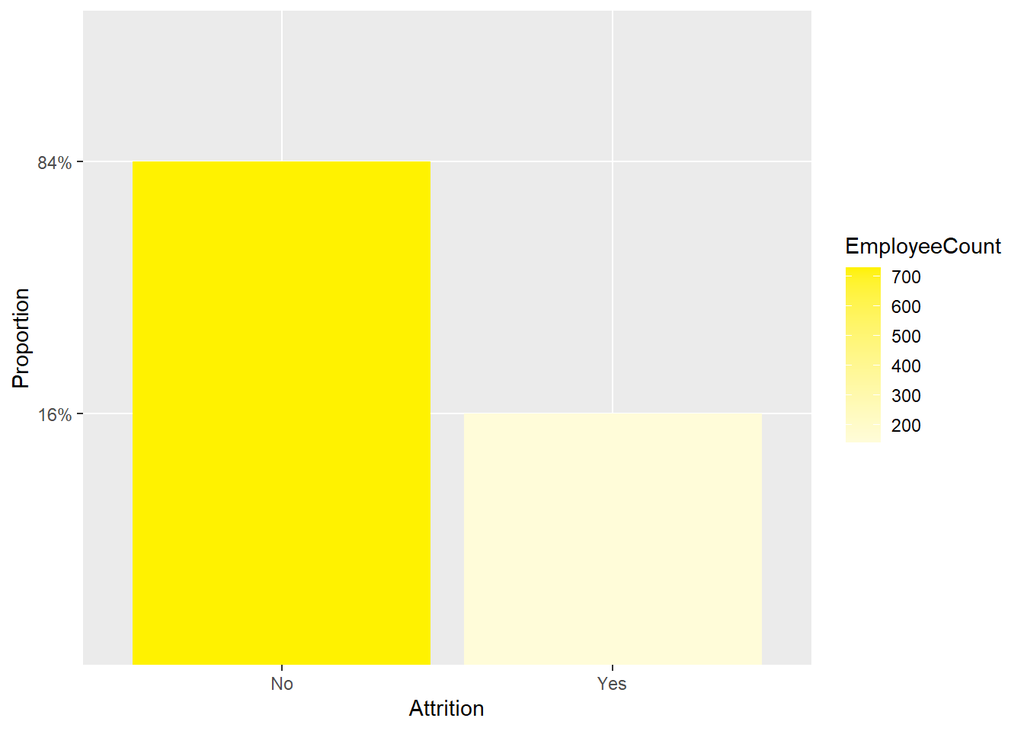

```r
ggplot(data= data1,aes(x=Attrition,y=  Proportion, fill = EmployeeCount))+geom_bar(stat = "identity")+ scale_fill_gradient2(low= '#971B1E', high = '#FFF200', space='#E1E1E1')
```

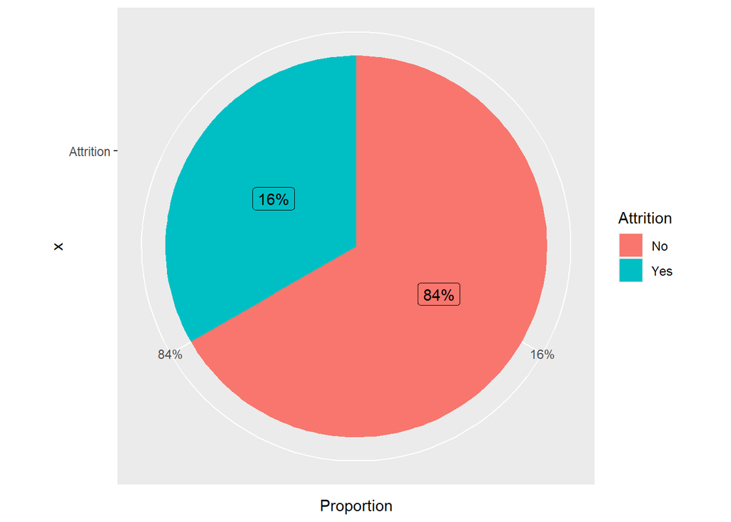

```r
ggplot(data1, aes(x = "Attrition", y = Proportion, fill = Attrition)) +
  geom_col() +
  coord_polar(theta = "y")+ geom_label(aes(label = Proportion),
             position = position_stack(vjust = 0.5),
             show.legend = FALSE)
```

### Age

```r
summary(data$Age)
```

```
##    Min. 1st Qu.  Median    Mean 3rd Qu.    Max.
##   18.00   30.00   35.00   36.83   43.00   60.00
```

```r
range(data$Age)
```

```
## [1] 18 60
```

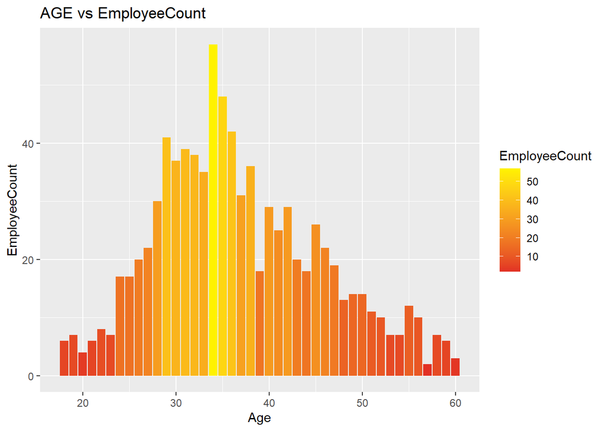

```r
Agedf <- data %>% group_by(Age)%>% summarise(EmployeeCount =n())

ggplot(data=Agedf,aes(x=Age,y = EmployeeCount, fill = EmployeeCount ))+ geom_bar(stat ="identity")+ggtitle("AGE vs EmployeeCount") + scale_fill_gradient2(low= '#971B1E', mid = '#E02124', high = '#FFF200', space='#E1E1E1')
```

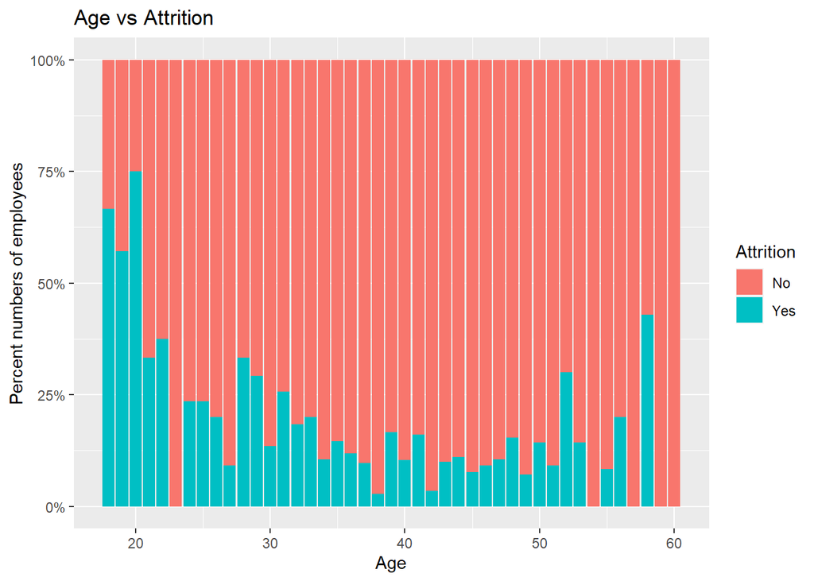

```r
ggplot(data, aes_string(x = "Age", fill = "Attrition")) +
  geom_bar(position = "fill") +
  scale_y_continuous(labels = scales::percent) +
  xlab("Age") + ylab("Percent numbers of employees") + ggtitle("Age vs Attrition")
```

```r
range(data$MonthlyIncome)
```

```
## [1]  1081 19999
```

### Monthly income and Attrition. Less income employee are more likely to quit the job.

```r
summary(data$MonthlyIncome)
```

```
##    Min. 1st Qu.  Median    Mean 3rd Qu.    Max.
##    1081    2840    4946    6390    8182   19999
```

```r
range(data$MonthlyIncome)
```

```
## [1]  1081 19999
```

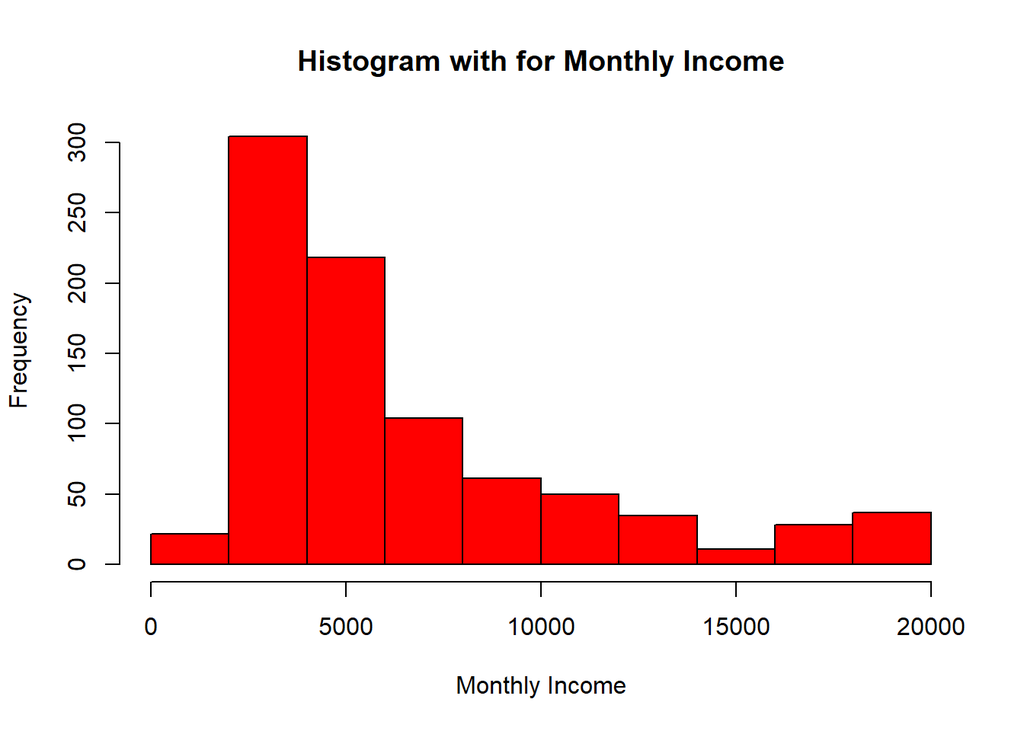

```r
h<-hist(data$MonthlyIncome, breaks=10, col="red", xlab="Monthly Income",
        main="Histogram with for Monthly Income")
```

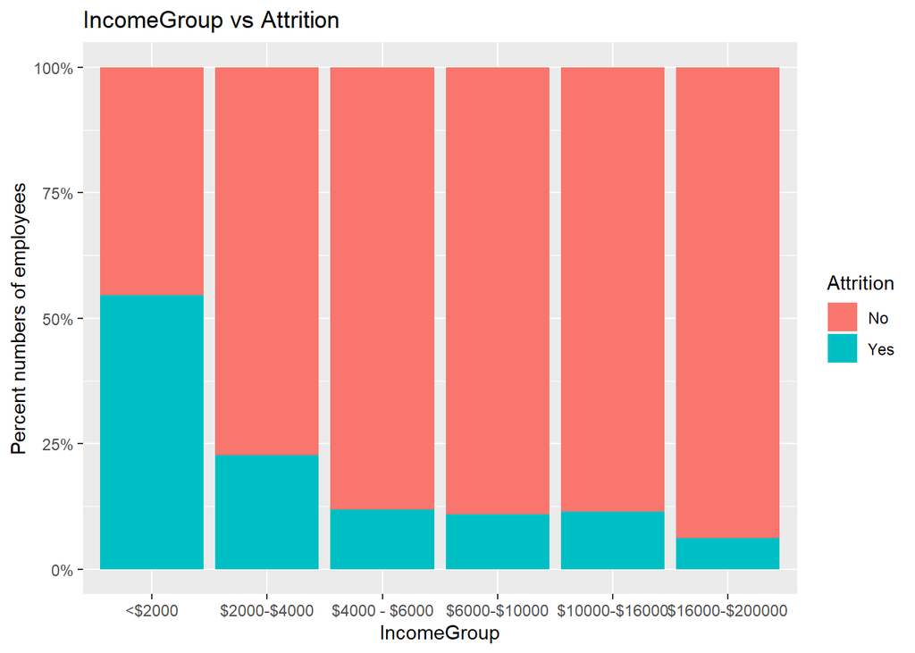

```r
###Right skewed

##Now grouping the employee based on salary

data$IncomeGroup <- cut(data$MonthlyIncome, c(0,2000,4000,6000,10000,16000,20000), labels = c("<$2000","$2000-$4000","$4000 - $6000","$6000-$10000","$10000-$16000","$16000-$200000"), include.lowest = TRUE)


ggplot(data, aes_string(x = "IncomeGroup", fill = "Attrition")) +
  geom_bar(position = "fill") +
  scale_y_continuous(labels = scales::percent) +
   xlab("IncomeGroup") + ylab("Percent numbers of employees") + ggtitle("IncomeGroup vs Attrition")
```

###BusinessTravel

```r
data$BusinessTravel <- as.factor(data$BusinessTravel)
BusinessTraveldf<- data %>% group_by(BusinessTravel) %>% summarise(EmployeeCount =n(), Proportion = scales::percent(n()/dim(data)[1]))
BusinessTraveldf
```

```
## # A tibble: 3 x 3
##   BusinessTravel    EmployeeCount Proportion
##   <fct>                     <int> <chr>
## 1 Non-Travel                   94 11%
## 2 Travel_Frequently           158 18%
## 3 Travel_Rarely               618 71%
```

[figure not shown]

```r
ggplot(data=BusinessTraveldf,aes(x=BusinessTravel,y = EmployeeCount, fill = EmployeeCount ))+ geom_bar(stat ="identity")+ggtitle("Department vs EmployeeCount") + scale_fill_gradient2(low= '#971B1E', mid = '#E02124', high = '#FFF200', space='#E1E1E1') + geom_text(aes(x= BusinessTravel,EmployeeCount + 25, label = EmployeeCount, fill = NULL), data = BusinessTraveldf)
```

[figure not shown]

```r
ggplot(data, aes_string(x = "BusinessTravel", fill = "Attrition")) +
  geom_bar(position = "fill") +
  scale_y_continuous(labels = scales::percent) +
  xlab("Department") + ylab("Percent numbers of employees") + ggtitle("BusinessTravel vs Attrition")
```

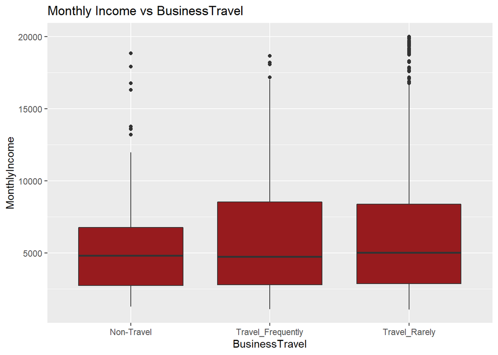

```r
ggplot(data,aes_string(x= "BusinessTravel" , y ="MonthlyIncome", fill ="BusinessTravel" ))+geom_boxplot(fill=c('#971B1E'))+ggtitle("Monthly Income vs BusinessTravel")
```

####Distance from home

```r
data$DistanceFromHome <- as.factor(data$DistanceFromHome)
DistanceFromHomedf<- data %>% group_by(DistanceFromHome) %>% summarise(EmployeeCount =n(), Proportion = scales::percent(n()/dim(data)[1]))
DistanceFromHomedf
```

```
## # A tibble: 29 x 3
##    DistanceFromHome EmployeeCount Proportion
##    <fct>                    <int> <chr>
##  1 1                          112 13%
##  2 2                          133 15%
##  3 3                           45 5%
##  4 4                           44 5%
##  5 5                           33 4%
##  6 6                           37 4%
##  7 7                           50 6%
##  8 8                           48 6%
##  9 9                           50 6%
## 10 10                          48 6%
## # ... with 19 more rows
```

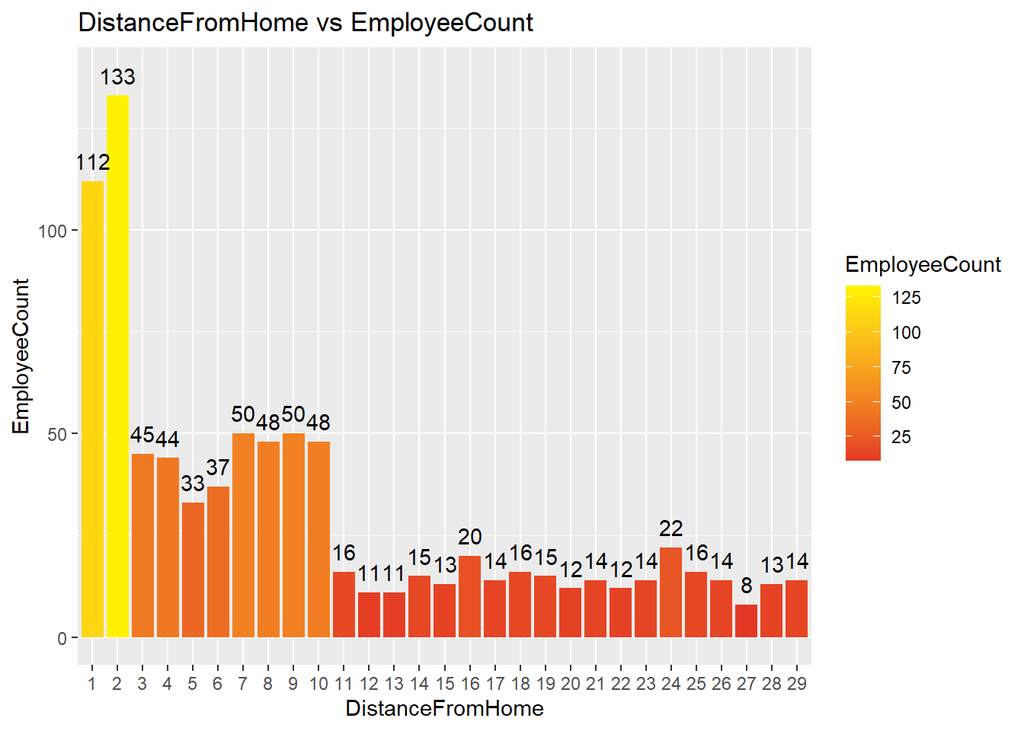

```r
ggplot(data=DistanceFromHomedf,aes(x=DistanceFromHome,y = EmployeeCount, fill = EmployeeCount ))+ geom_bar(stat ="identity")+ggtitle("DistanceFromHome vs EmployeeCount") + scale_fill_gradient2(low= '#971B1E', mid = '#E02124', high = '#FFF200', space='#E1E1E1') + geom_text(aes(x= DistanceFromHome,EmployeeCount +5, label = EmployeeCount, fill = NULL), data = DistanceFromHomedf)
```

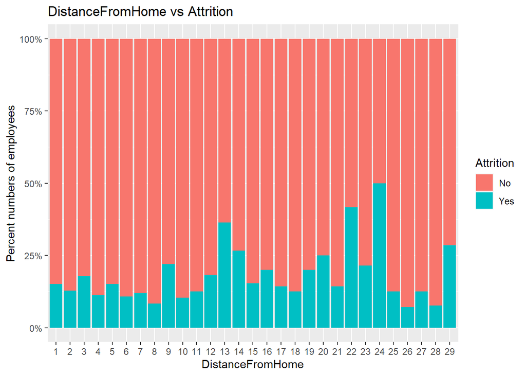

```r
ggplot(data, aes_string(x = "DistanceFromHome", fill = "Attrition")) +
  geom_bar(position = "fill") +
  scale_y_continuous(labels = scales::percent) +
  xlab("DistanceFromHome") + ylab("Percent numbers of employees") + ggtitle("DistanceFromHome vs Attrition")
```

###Department

```r
data$Department <- as.factor(data$Department)
Deparmentdf<- data %>% group_by(Department) %>% summarise(EmployeeCount =n(), Proportion = scales::percent(n()/dim(data)[1]))
Deparmentdf
```

```
## # A tibble: 3 x 3
##   Department             EmployeeCount Proportion
##   <fct>                          <int> <chr>
## 1 Human Resources                   35 4%
## 2 Research & Development           562 65%
## 3 Sales                            273 31%
```

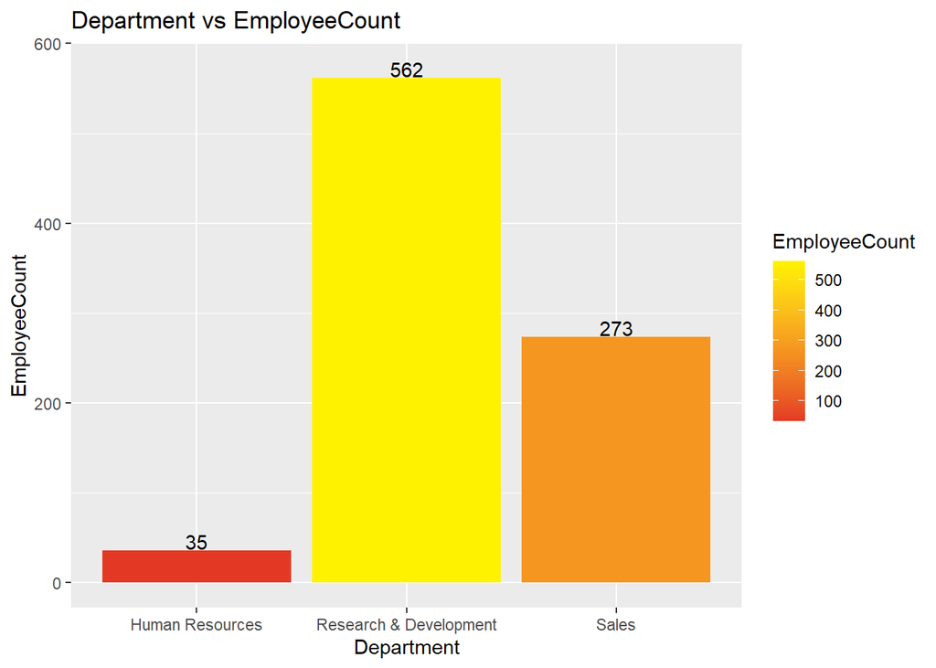

```r
ggplot(data=Deparmentdf,aes(x=Department,y = EmployeeCount, fill = EmployeeCount ))+ geom_bar(stat ="identity")+ggtitle("Department vs EmployeeCount") + scale_fill_gradient2(low= '#971B1E', mid = '#E02124', high = '#FFF200', space='#E1E1E1')+ geom_text(aes(x= Department,EmployeeCount +10, label = EmployeeCount, fill = NULL), data = Deparmentdf)
```

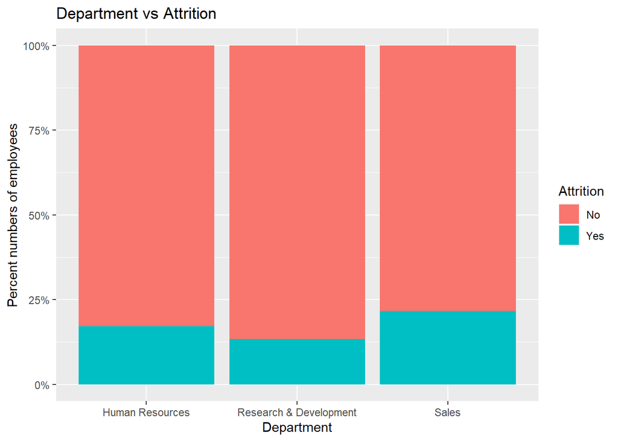

```r
ggplot(data, aes_string(x = "Department", fill = "Attrition")) +
  geom_bar(position = "fill") +
  scale_y_continuous(labels = scales::percent) +
 xlab("Department") + ylab("Percent numbers of employees") + ggtitle("Department vs Attrition")
```

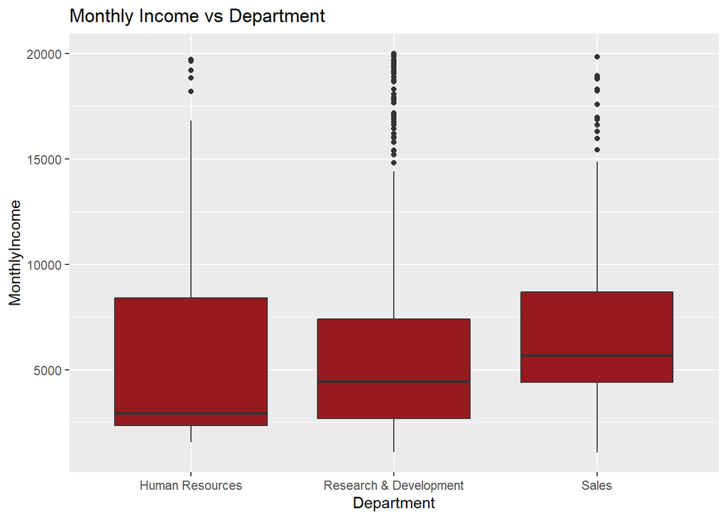

```r
ggplot(data,aes_string(x= "Department" , y ="MonthlyIncome", fill ="Department" ))+geom_boxplot(fill=c('#971B1E'))+ggtitle("Monthly Income vs Department")
```

####Distance from home

```r
data$DistanceFromHome <- as.factor(data$DistanceFromHome)
DistanceFromHomedf<- data %>% group_by(DistanceFromHome) %>% summarise(EmployeeCount =n(), Proportion = scales::percent(n()/dim(data)[1]))
DistanceFromHomedf
```

```
## # A tibble: 29 x 3
##    DistanceFromHome EmployeeCount Proportion
##    <fct>                    <int> <chr>
##  1 1                          112 13%
##  2 2                          133 15%
##  3 3                           45 5%
##  4 4                           44 5%
##  5 5                           33 4%
##  6 6                           37 4%
##  7 7                           50 6%
##  8 8                           48 6%
##  9 9                           50 6%
## 10 10                          48 6%
## # ... with 19 more rows
```

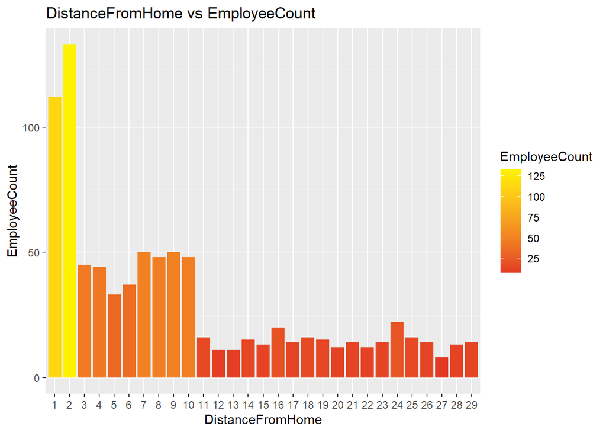

```r
ggplot(data=DistanceFromHomedf,aes(x=DistanceFromHome,y = EmployeeCount, fill = EmployeeCount ))+ geom_bar(stat ="identity")+ggtitle("DistanceFromHome vs EmployeeCount") + scale_fill_gradient2(low= '#971B1E', mid = '#E02124', high = '#FFF200', space='#E1E1E1')
```

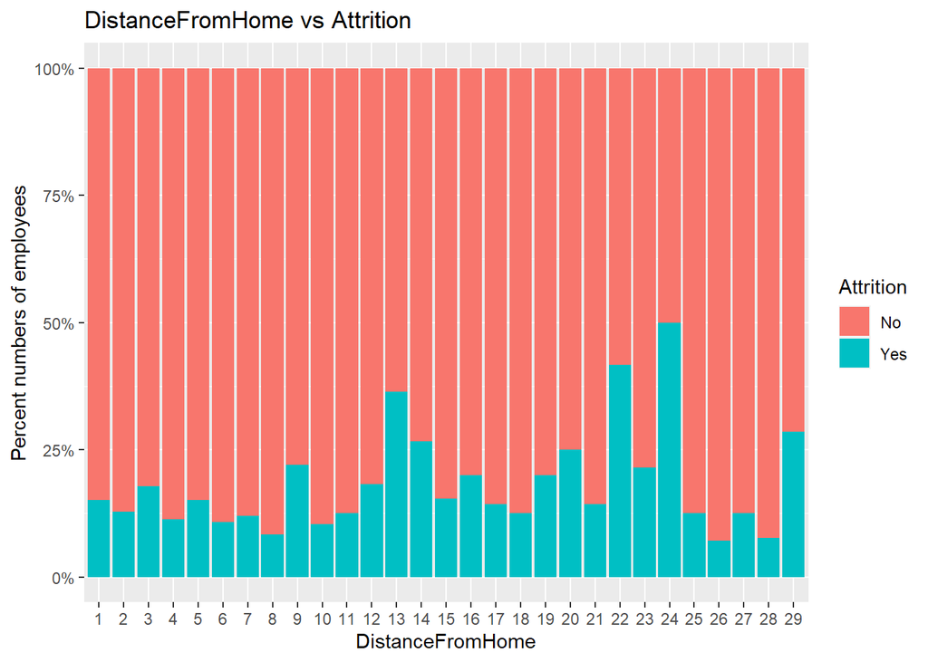

```r
ggplot(data, aes_string(x = "DistanceFromHome", fill = "Attrition")) +
  geom_bar(position = "fill") +
  scale_y_continuous(labels = scales::percent) +
  xlab("DistanceFromHome") + ylab("Percent numbers of employees") + ggtitle("DistanceFromHome vs Attrition")
```

###Education

```r
data$Education <- as.factor(data$Education)
Educationdf <-data %>% group_by(Education) %>% summarise(EmployeeCount =n(), Proportion = scales::percent(n()/dim(data)[1]))
Educationdf
```

```
## # A tibble: 5 x 3
##   Education EmployeeCount Proportion
##   <fct>             <int> <chr>
## 1 1                    98 11%
## 2 2                   182 21%
## 3 3                   324 37%
## 4 4                   240 28%
## 5 5                    26 3%
```

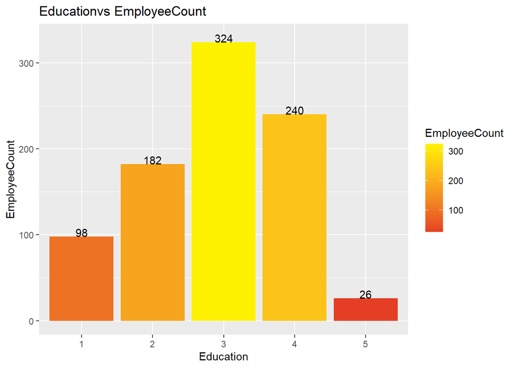

```r
ggplot(data=Educationdf,aes(x=Education,y = EmployeeCount, fill = EmployeeCount ))+ geom_bar(stat ="identity")+ggtitle("Educationvs EmployeeCount") + scale_fill_gradient2(low= '#971B1E', mid = '#E02124', high = '#FFF200', space='#E1E1E1') + geom_text(aes(x= Education,EmployeeCount +5, label = EmployeeCount, fill = NULL), data = Educationdf)
```

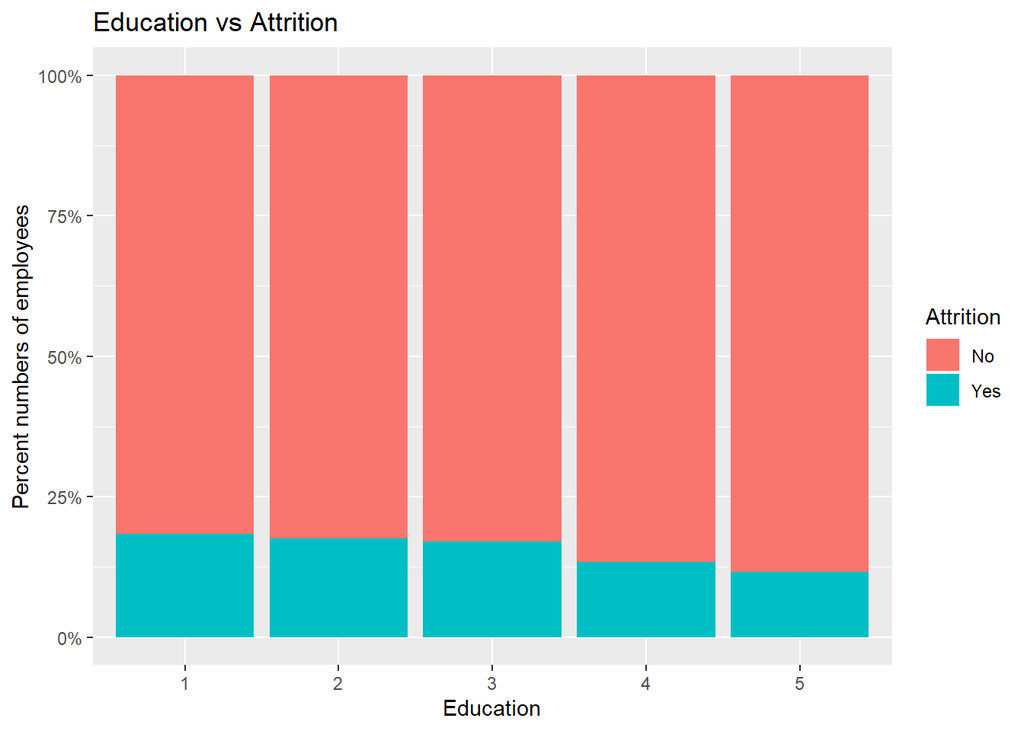

```r
ggplot(data, aes_string(x = "Education", fill = "Attrition")) +
  geom_bar(position = "fill") +
  scale_y_continuous(labels = scales::percent) +
  xlab("Education") + ylab("Percent numbers of employees") + ggtitle("Education vs Attrition")
```

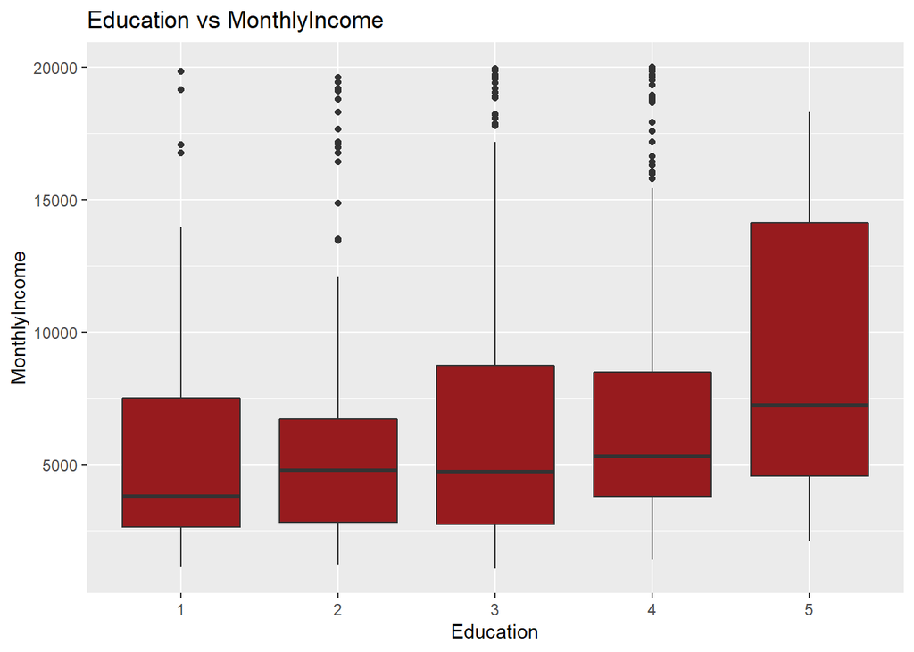

```r
ggplot(data,aes_string(x= "Education" , y ="MonthlyIncome", fill ="Education" ))+geom_boxplot(fill=c('#971B1E'))+ggtitle("Education vs MonthlyIncome")
```

###Educationfield

```r
data$EducationField <- as.factor(data$EducationField)
EducationFielddf <-data %>% group_by(EducationField) %>% summarise(EmployeeCount =n(), Proportion = scales::percent(n()/dim(data)[1]))
EducationFielddf
```

```
## # A tibble: 6 x 3
##   EducationField   EmployeeCount Proportion
##   <fct>                    <int> <chr>
## 1 Human Resources             15 2%
## 2 Life Sciences              358 41%
## 3 Marketing                  100 11%
## 4 Medical                    270 31%
## 5 Other                       52 6%
## 6 Technical Degree            75 9%
```

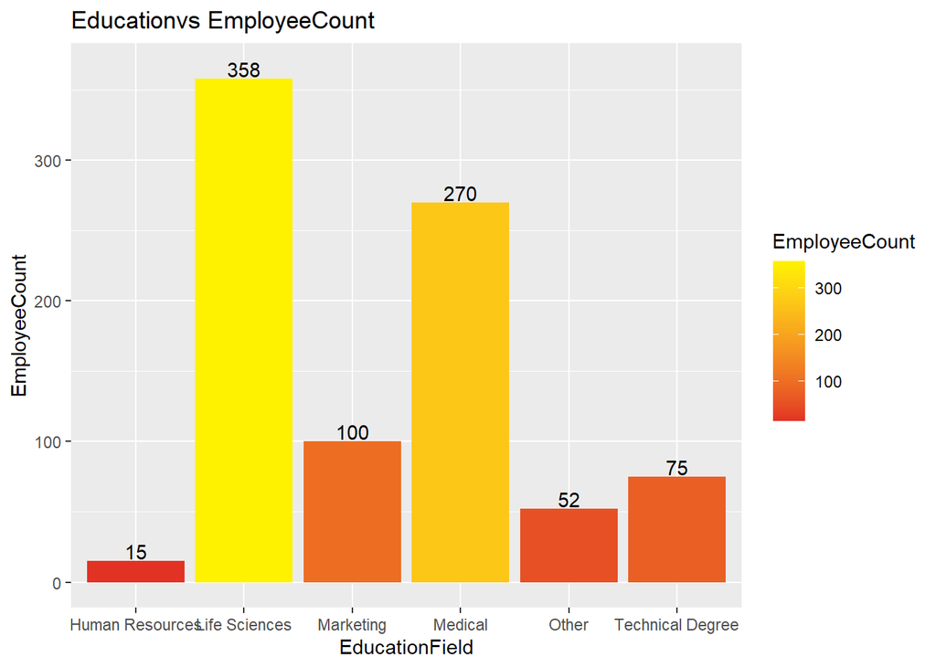

```r
ggplot(data=EducationFielddf,aes(x=EducationField,y = EmployeeCount, fill = EmployeeCount ))+ geom_bar(stat ="identity")+ggtitle("Educationvs EmployeeCount") + scale_fill_gradient2(low= '#971B1E', mid = '#E02124', high = '#FFF200', space='#E1E1E1') + geom_text(aes(x= EducationField, EmployeeCount +7, label = EmployeeCount, fill = NULL), data = EducationFielddf)
```

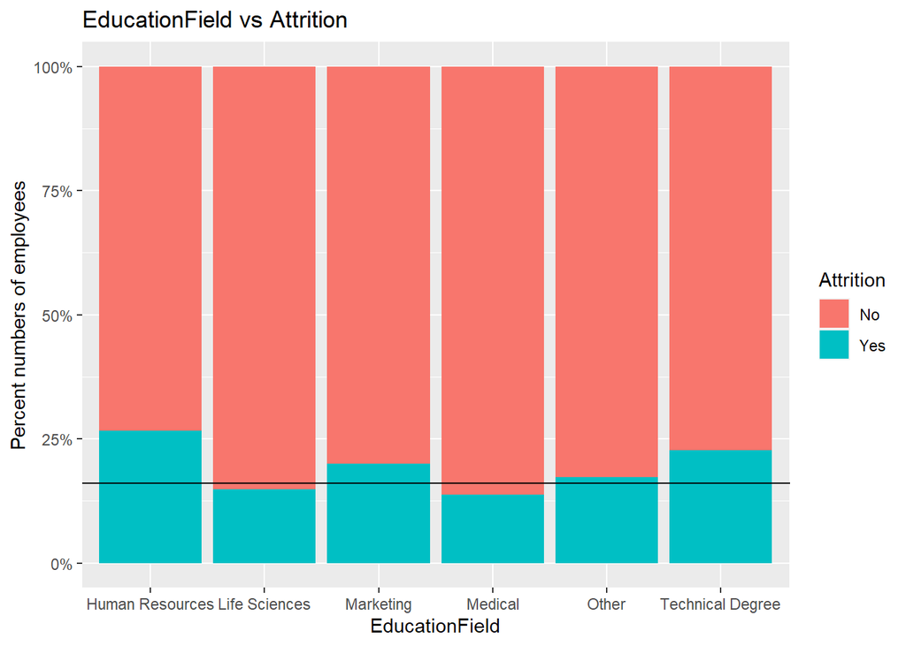

```r
ggplot(data, aes_string(x = "EducationField", fill = "Attrition")) +
  geom_bar(position = "fill") +
  scale_y_continuous(labels = scales::percent) +
  geom_abline(slope = 0, intercept = .16) + xlab("EducationField") + ylab("Percent numbers of employees") + ggtitle("EducationField vs Attrition")
```

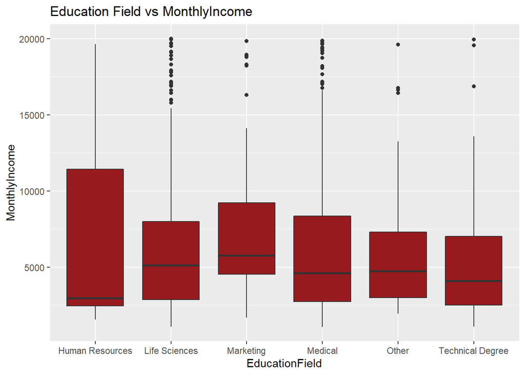

```r
ggplot(data,aes_string(x= "EducationField" , y ="MonthlyIncome", fill ="EducationField" ))+geom_boxplot(fill=c('#971B1E'))+ggtitle("Education Field vs MonthlyIncome")
```

### Environment Satisfaction

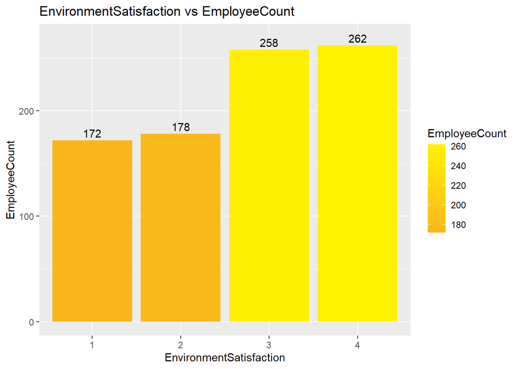

```r
data$EnvironmentSatisfaction <- as.factor(data$EnvironmentSatisfaction)
EnvironmentSatisfactiondf <-data %>% group_by(EnvironmentSatisfaction) %>% summarise(EmployeeCount =n(), Proportion = scales::percent(n()/dim(data)[1]))

ggplot(data=EnvironmentSatisfactiondf,aes(x=EnvironmentSatisfaction,y = EmployeeCount, fill = EmployeeCount ))+ geom_bar(stat ="identity")+ggtitle("EnvironmentSatisfaction vs EmployeeCount") + scale_fill_gradient2(low= '#971B1E', mid = '#E02124', high = '#FFF200', space='#E1E1E1')+ geom_text(aes(x= EnvironmentSatisfaction, EmployeeCount +7, label = EmployeeCount, fill = NULL), data = EnvironmentSatisfactiondf)
```

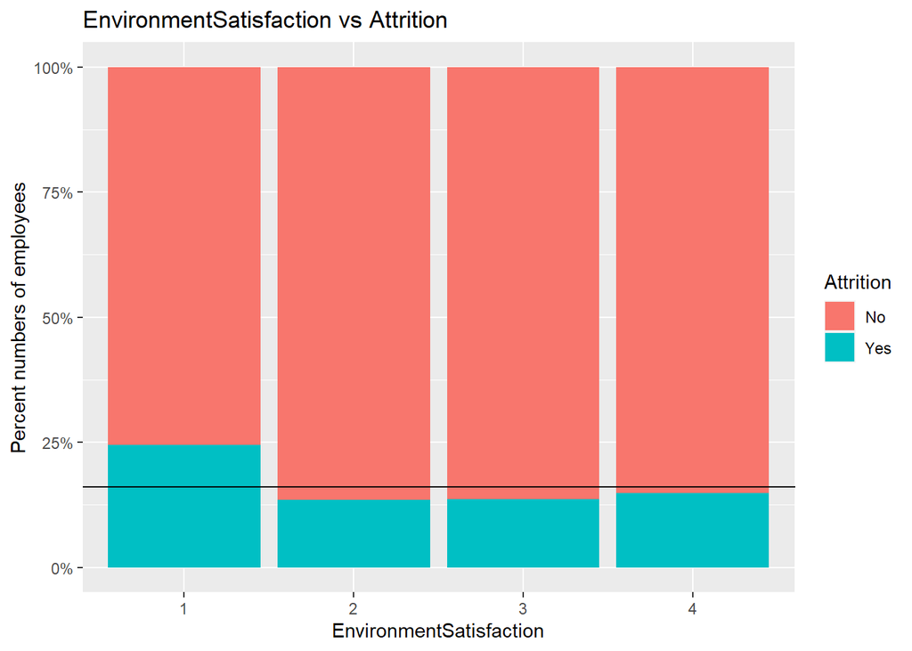

```r
ggplot(data, aes_string(x = "EnvironmentSatisfaction", fill = "Attrition")) +
  geom_bar(position = "fill") +
  scale_y_continuous(labels = scales::percent) +
  geom_abline(slope = 0, intercept = .16) + xlab("EnvironmentSatisfaction") + ylab("Percent numbers of employees") + ggtitle("EnvironmentSatisfaction vs Attrition")
```

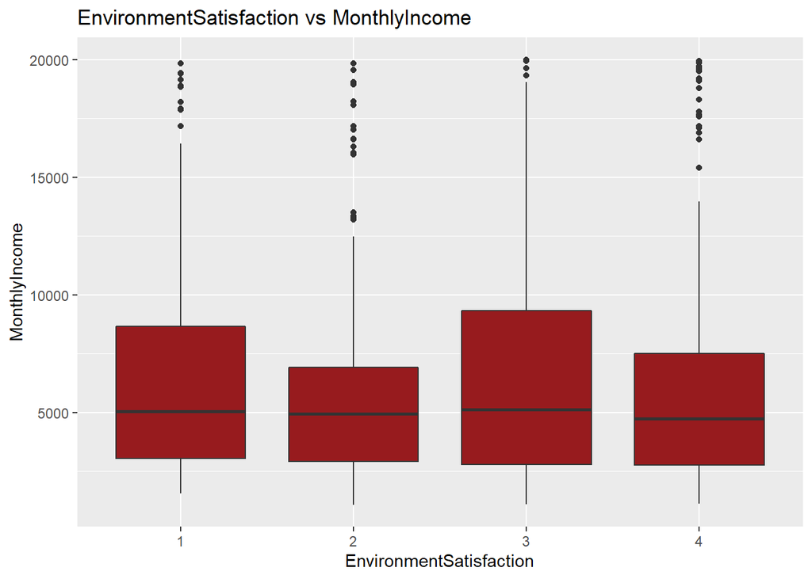

```r
ggplot(data,aes_string(x= "EnvironmentSatisfaction" , y ="MonthlyIncome", fill ="EnvironmentSatisfaction" ))+geom_boxplot(fill=c('#971B1E'))+ggtitle("EnvironmentSatisfaction vs MonthlyIncome")
```

###Gender

```r
data$Gender <- as.factor(data$Gender)
Genderdf <-data %>% group_by(Gender) %>% summarise(EmployeeCount =n(), Proportion = scales::percent(n()/dim(data)[1]))
Genderdf
```

```
## # A tibble: 2 x 3
##   Gender EmployeeCount Proportion
##   <fct>          <int> <chr>
## 1 Female           354 41%
## 2 Male             516 59%
```

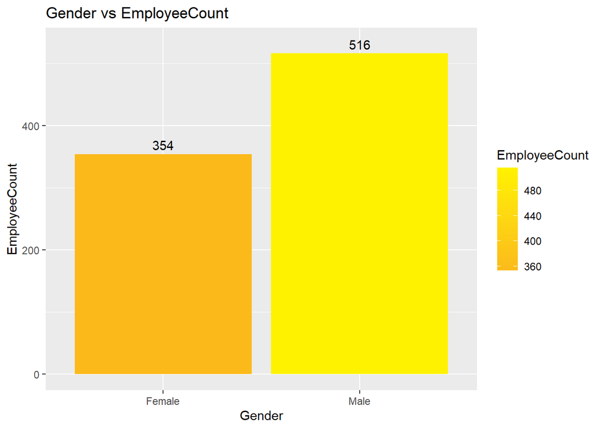

```r
ggplot(data=Genderdf,aes(x=Gender,y = EmployeeCount, fill = EmployeeCount ))+ geom_bar(stat ="identity")+ggtitle("Gender vs EmployeeCount") + scale_fill_gradient2(low= '#971B1E', mid = '#E02124', high = '#FFF200', space='#E1E1E1')+ geom_text(aes(x= Gender, EmployeeCount +15, label = EmployeeCount, fill = NULL), data = Genderdf)
```

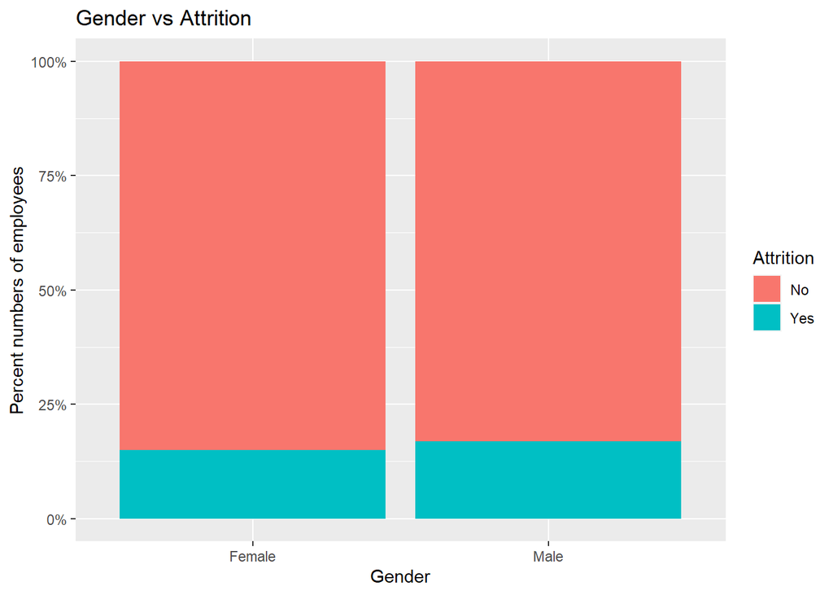

```r
ggplot(data, aes_string(x = "Gender", fill = "Attrition")) +
  geom_bar(position = "fill") +
  scale_y_continuous(labels = scales::percent) +
  xlab("Gender") + ylab("Percent numbers of employees") + ggtitle("Gender vs Attrition")
```

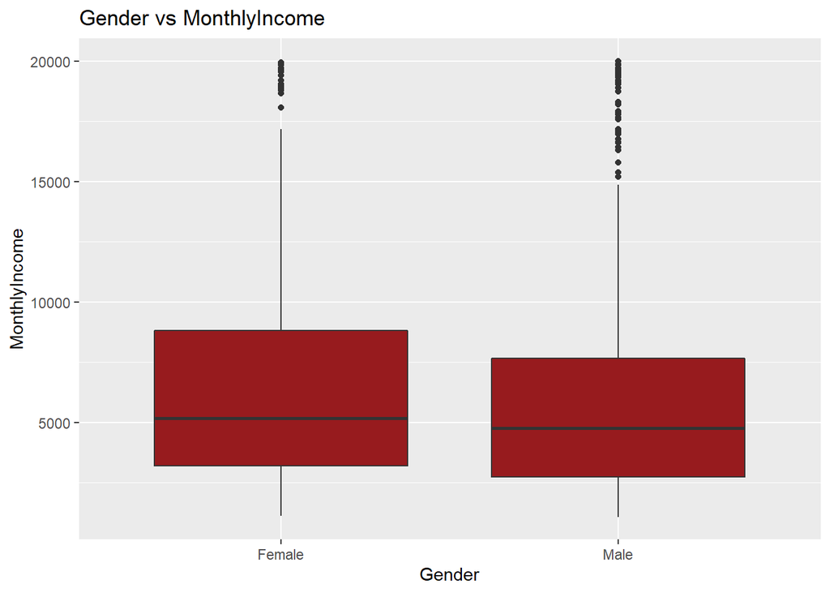

```r
ggplot(data,aes_string(x= "Gender" , y ="MonthlyIncome", fill ="Gender" ))+geom_boxplot(fill=c('#971B1E'))+ggtitle("Gender vs MonthlyIncome")
```

###JobInvolvement

```r
data$JobInvolvement <- as.factor(data$JobInvolvement)
JobInvolvementdf <-data %>% group_by(JobInvolvement) %>% summarise(EmployeeCount =n(), Proportion = scales::percent(n()/dim(data)[1]))
JobInvolvementdf
```

```
## # A tibble: 4 x 3
##   JobInvolvement EmployeeCount Proportion
##   <fct>                  <int> <chr>
## 1 1                         47 5%
## 2 2                        228 26%
## 3 3                        514 59%
## 4 4                         81 9%
```

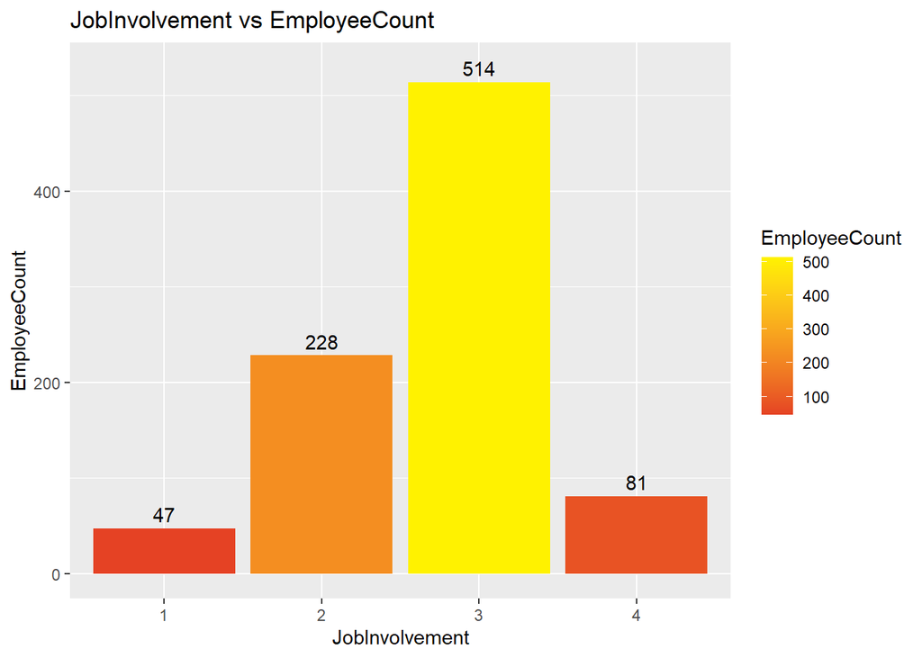

```r
ggplot(data=JobInvolvementdf,aes(x=JobInvolvement,y = EmployeeCount, fill = EmployeeCount ))+ geom_bar(stat ="identity")+ggtitle("JobInvolvement vs EmployeeCount") + scale_fill_gradient2(low= '#971B1E', mid = '#E02124', high = '#FFF200', space='#E1E1E1') + geom_text(aes(x= JobInvolvement, EmployeeCount +15, label = EmployeeCount, fill = NULL), data = JobInvolvementdf)
```

[figure not shown]

```r
ggplot(data, aes_string(x = "JobInvolvement", fill = "Attrition")) +
  geom_bar(position = "fill") +
  scale_y_continuous(labels = scales::percent) +
   xlab("JobInvolvement") + ylab("Percent numbers of employees") + ggtitle("Gender vs Attrition")
```

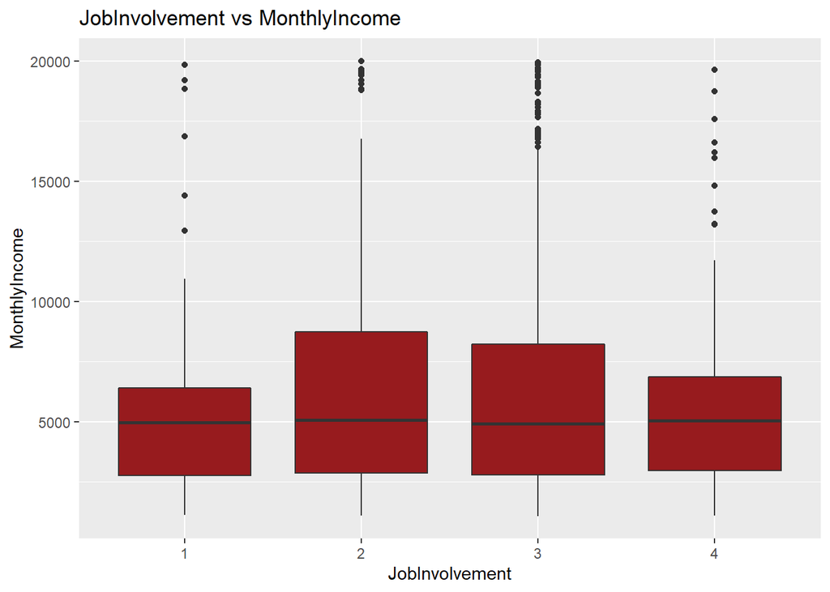

```r
ggplot(data,aes_string(x= "JobInvolvement" , y ="MonthlyIncome", fill ="JobInvolvement" ))+geom_boxplot(fill=c('#971B1E'))+ggtitle("JobInvolvement vs MonthlyIncome")
```

###JobLevel###important linear relationship

```r
data$JobLevel <- as.factor(data$JobLevel)
JobLeveldf <-data %>% group_by(JobLevel) %>% summarise(EmployeeCount =n(), Proportion = scales::percent(n()/dim(data)[1]))
JobLeveldf
```

```
## # A tibble: 5 x 3
##   JobLevel EmployeeCount Proportion
##   <fct>            <int> <chr>
## 1 1                  329 38%
## 2 2                  312 36%
## 3 3                  132 15%
## 4 4                   60 7%
## 5 5                   37 4%
```